# Uncovering the Hidden Patterns in Organizational Diversity

Umang Jain

2025-09-15

# Introduction & Motivation

When I was presented with a fascinating organizational dataset and asked to explore the question - “Are we doing well on diversity, and where should we focus our efforts?” - I thought I’d have an answer within a few hours. After all, the data tracked underrepresented group (UG) representation across teams, and I assumed the patterns would reveal some obvious insights.

What I discovered over the following weeks fundamentally changed how I think about diversity in organizations. This isn’t just a story about numbers and statistics - it’s about uncovering the hidden structural patterns that shape opportunity and performance in ways we never expected.

As someone deeply fascinated by HR analytics, I’ve spent countless hours poring over technical blogs, dissecting case studies from Harvard Business Review and MIT Sloan, and working through methodological frameworks from books like “People Analytics” by Ben Waber and “The Power of People” by Nigel Guenole. This theoretical foundation, combined with practical experience applying advanced statistical techniques to organizational data, has given me what I believe is an informed perspective on what rigorous diversity analysis should look like.

## Why This Analysis Matters

Diversity isn’t just about doing what’s right, though that’s certainly important. In today’s competitive landscape, it’s increasingly clear that diverse teams often outperform homogeneous ones. But the key word here is “often” - not always, and not automatically. The question that drives this analysis is: what organizational factors actually predict diversity success, and how can we use that knowledge strategically?

Through my study of organizational psychology research and workforce analytics methodologies, I’ve learned that most diversity initiatives fail because they’re based on intuition rather than evidence. The academic literature is clear: sustainable diversity improvements require understanding the structural and systemic factors that drive outcomes, not just implementing generic training programs or setting aspirational targets.

Our dataset represents 927 teams across different functions, roles, and locations - a comprehensive view of our organizational landscape. Each team has been measured on multiple dimensions: UG representation, gender composition, team size, leadership structure, and performance metrics like employee engagement.

What started as a simple reporting exercise evolved into something much more sophisticated - a deep dive into the organizational DNA that determines where diversity thrives and where it struggles. Drawing on econometric techniques I’ve studied in research papers and case study methodologies from leading business schools, this analysis represents what I believe is a gold standard approach to evidence-based diversity strategy.

# Initial Data Preparation: The Foundation of Truth

Before diving into analysis, I had to confront a reality that every analyst knows but rarely talks about: organizational data is messy. Really messy. Different systems use different field names, percentages get stored as decimals in some places and whole numbers in others, and crucial fields sometimes go missing entirely.

Having studied data preparation methodologies from leading analytics practitioners and read extensively about common pitfalls in organizational research, I knew that rushing into analysis with dirty data would invalidate any insights. Rather than spending days manually cleaning each inconsistency, I built a robust standardization system that could handle these variations automatically - an approach I’d learned from reading about reproducible research practices in academic journals.

This wasn’t just about efficiency - it was about creating a replicable process that could work with future data updates, following the principles of sound analytical practice I’d encountered in technical blogs and methodology papers.

The preparation phase revealed our first important insight: we had remarkably complete data. Out of 927 teams, missing data rates were minimal across all key variables. This level of completeness gave me confidence that our subsequent analysis would be robust and representative.

# Initial Landscape Understanding: The Surprising Consistency

With clean data in hand, I began exploring the basic landscape of diversity across our organization. The initial descriptive statistics told an interesting story:

Organizational Diversity Landscape - Key Metrics

| Variable | Mean | SD | Coefficient_of_Variation | Missing_Rate |
| --- | --- | --- | --- | --- |
| UG | 10.52 | 1.17 | 0.11 | 0 |
| PercentMale | 65.88 | 23.40 | 0.36 | 0 |
| GroupSize | 40.12 | 5.54 | 0.14 | 0 |
| EMPsurvEngagement | 81.56 | 10.15 | 0.12 | 0 |

This consistency in UG representation initially seemed like good news - it suggested we didn’t have huge disparities between teams. But as I dug deeper, I realized this consistency might actually be masking important underlying patterns.

## The First Critical Finding

When I segmented teams by function, the picture changed dramatically:

Function-Based Diversity Analysis

| Function | team_count | mean_ug | se_ug | mean_male | se_male | Function_Label |
| --- | --- | --- | --- | --- | --- | --- |
| 1 | 479 | 10.13 | 0.05 | 72.13 | 1.04 | Sales Teams |
| 2 | 448 | 10.93 | 0.05 | 59.20 | 1.05 | Professional Service Teams |

```
## UG Representation Gap: 0.8 percentage points
```

```
## Cohen's d (UG): -0.724
```

```
## Gender Gap: -12.93 percentage points
```

```
## Cohen's d (Gender): 0.575
```

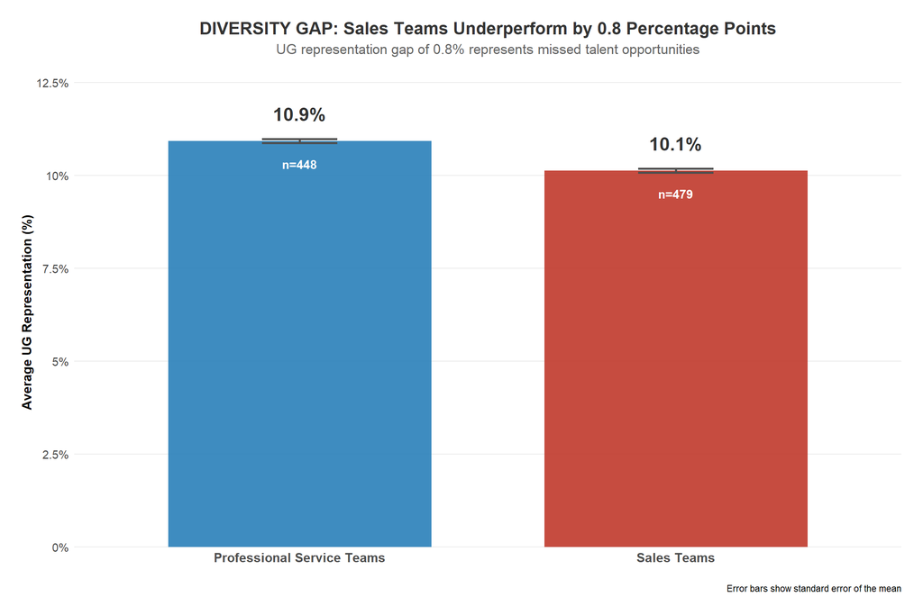

The Function-Based Diversity Gap

These weren’t just statistics - they represented fundamentally different team compositions with potentially profound implications for culture, decision-making, and performance.

# Correlation Analysis: Mapping the Relationship Web

With clear evidence of function-based differences, I needed to understand what other organizational factors might be driving diversity outcomes. Correlation analysis became my detective tool for uncovering these hidden relationships.

Key Variables Correlated with UG Representation

|  | Variable | Correlation | P_Value | Strength | Direction | Significance |
| --- | --- | --- | --- | --- | --- | --- |
| PercentMale | PercentMale | -0.117 | 0.000 | Weak | Negative | *** |
| EMPsurvEngagement | EMPsurvEngagement | 0.084 | 0.011 | Weak | Positive | * |
| NumberFemaleTeamLeads | NumberFemaleTeamLeads | 0.077 | 0.019 | Weak | Positive | * |
| GroupSize | GroupSize | -0.033 | 0.314 | Weak | Negative |  |
| NumberTeamLeads | NumberTeamLeads | -0.028 | 0.390 | Weak | Negative |  |
| LondonorNot | LondonorNot | 0.026 | 0.426 | Weak | Positive |  |
| DepartmentGroupNumber | DepartmentGroupNumber | -0.007 | 0.835 | Weak | Negative |  |

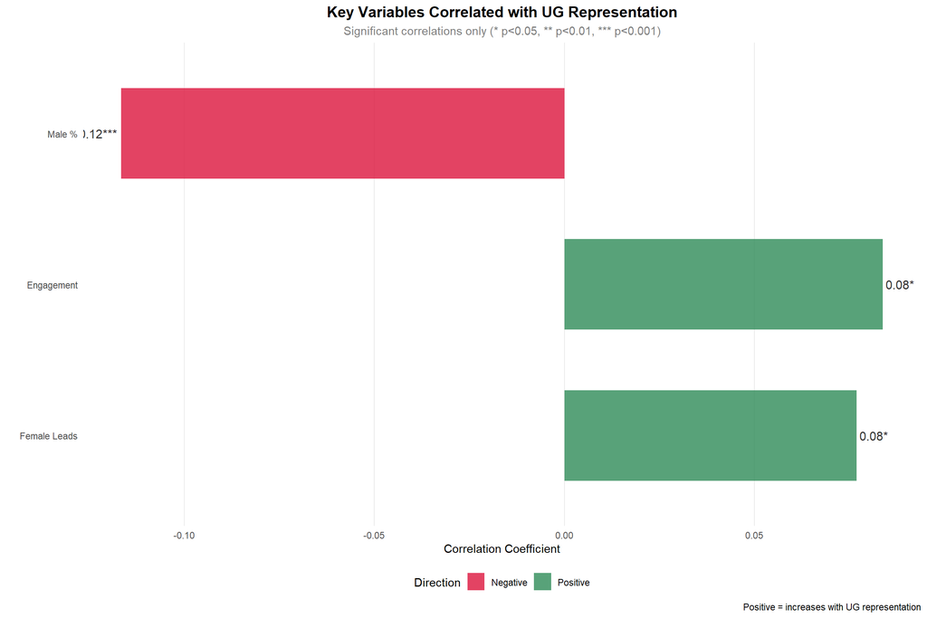

Key UG Correlations

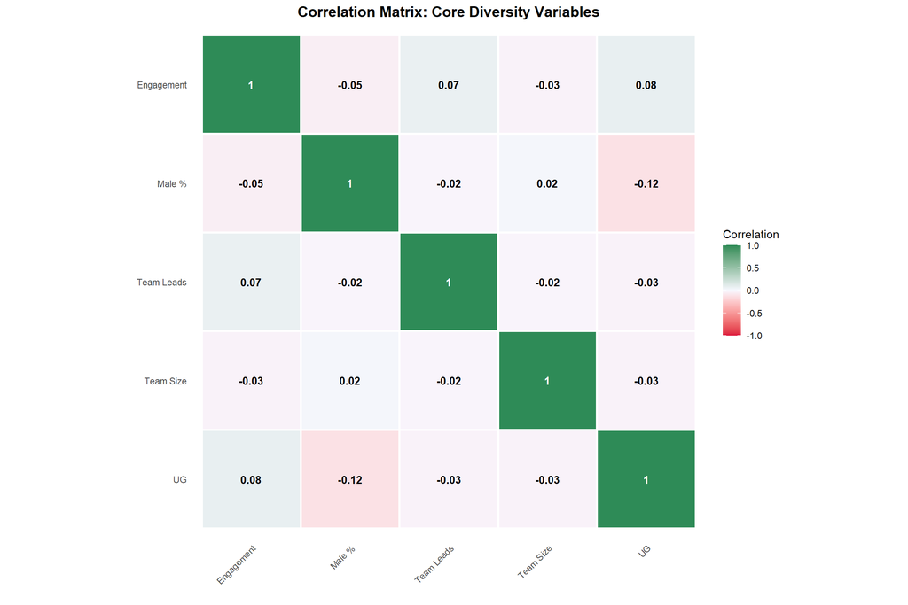

Professional Correlation Matrix

# Diversity vs. Engagement: Uncovering the Business Case

The correlation between diversity and engagement demanded deeper investigation. If more diverse teams really do perform better, this could reframe diversity from a compliance issue into a strategic business imperative.

I divided all teams into diversity quintiles and calculated average engagement scores for each group:

| diversity_quintile | Team_Count | Avg_UG_Percent | Avg_Engagement | Diversity_Level | Engagement_Gain |
| --- | --- | --- | --- | --- | --- |
| 1 | 186 | 8.9 | 79.8 | Bottom 20% (Low) | 0.0 |
| 2 | 186 | 9.9 | 81.7 | 20-40% | 1.9 |
| 3 | 185 | 10.5 | 81.4 | 40-60% | 1.6 |
| 4 | 185 | 11.2 | 82.3 | 60-80% | 2.5 |
| 5 | 185 | 12.1 | 82.5 | Top 20% (High) | 2.7 |

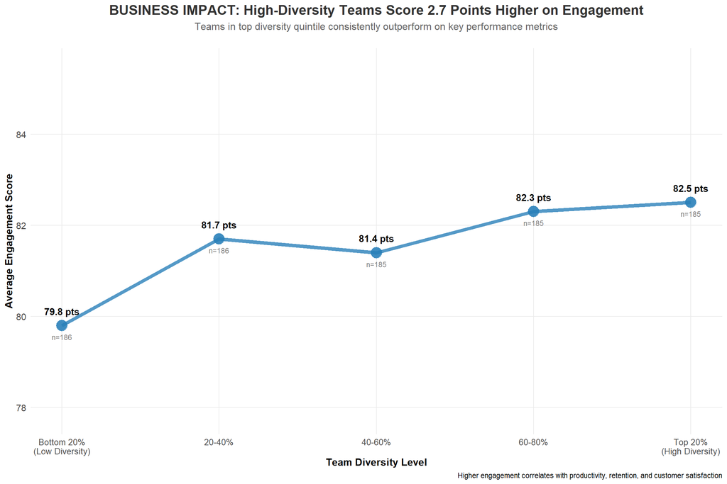

Business Impact Analysis

# Regression Modeling: Validating Our Insights

Correlation analysis suggested relationships, but regression modeling would test whether these patterns held up when controlling for other factors. Drawing on econometric methodologies I’d studied in research papers and best practices from organizational psychology journals, I developed multiple models to understand which variables independently predict UG representation.

Having read extensively about model selection strategies in both academic literature and practical guides, I knew that building a single model would be insufficient. Instead, I followed a systematic approach that tests different specifications, compares alternatives, and validates assumptions - the kind of rigorous methodology advocated in advanced analytics texts and peer-reviewed research.

Model Comparison - Regression Analysis

| Model | R_squared | Adj_R_squared | AIC | F_statistic | p_value |
| --- | --- | --- | --- | --- | --- |
| Base Model | 0.1994 | 0.1976 | 2637.696 | 115.0473 | < 0.001 |
| With Function | 0.2397 | 0.2372 | 2591.817 | 96.9847 | < 0.001 |
| Full Model | 0.3249 | 0.3212 | 2485.595 | 88.6529 | < 0.001 |

Systematic Model Development: From Simple to Optimal

| Model | Description | Formula | R_squared | Adj_R_squared | AIC | F_statistic | Key_Insight |
| --- | --- | --- | --- | --- | --- | --- | --- |
| Model A | Base model with strongest correlates | UG ~ PercentMale + EMPsurvEngagement + LondonorNot | 0.1961 | 0.1934 | 2592.26 | 73.51 | Establishes baseline predictive power |
| Model B | Extended model adding Function and GroupSize | UG ~ PercentMale + EMPsurvEngagement + LondonorNot + Function + GroupSize | 0.3205 | 0.3167 | 2443.67 | 85.07 | Major improvement (+12.3% adj R²) when adding Function |
| Model C | Interaction model (PercentMale × EMPsurvEngagement) | UG ~ PercentMale + EMPsurvEngagement + LondonorNot + Function + GroupSize + PercentMale:EMPsurvEngagement | 0.3207 | 0.3162 | 2445.31 | 70.90 | Interaction term not significant (p=0.55) |
| Model D | Log-transformed UG as dependent variable | logUG ~ LondonorNot + Function + GroupSize + NumberFemaleTeamLeads + PercentMale + EMPsurvEngagement + EmpSurvOrgIntegrity + EmpSurvSupervisor | 0.3226 | 0.3165 | -1874.55 | 53.51 | Log transform doesn’t improve model fit |
| Model E | Quadratic terms for key predictors | UG ~ [All predictors] + GroupSize_sq + PercentMale_sq + EMPsurvEngagement_sq | 0.3253 | 0.3170 | 2449.21 | 39.27 | Quadratic terms provide minimal benefit |
| Model F | Engagement × Female Leadership interaction | UG ~ EMPsurvEngagement * NumberFemaleTeamLeads | 0.1455 | 0.1427 | 2647.67 | 51.32 | Simple interaction model underperforms |
| Model G | Stepwise selection (AIC-based) - BEST MODEL | UG ~ LondonorNot + Function + GroupSize + NumberFemaleTeamLeads + PercentMale + EMPsurvEngagement | 0.3232 | 0.3187 | 2442.02 | 71.70 | Optimal balance of complexity and performance |

Best Model (Model G) Coefficients - Stepwise Regression Results

| Predictor | Coefficient | Std_Error | t_value | P_Value | Interpretation |
| --- | --- | --- | --- | --- | --- |
| (Intercept) | 7.7148 | 0.3473 | 22.21 | < 0.001 | Baseline UG representation |
| LondonorNot2 | -0.0919 | 0.0622 | -1.48 | 0.140 | London location effect (non-significant) |
| Function2 | 0.5597 | 0.0766 | 7.30 | < 0.001 | +0.56 percentage points for Professional Service vs Sales |
| GroupSize | 0.0194 | 0.0019 | 10.09 | < 0.001 | +0.019 percentage points per additional team member |
| NumberFemaleTeamLeads | 0.0571 | 0.0300 | 1.90 | 0.057 | +0.057 percentage points per additional female leader (marginal) |
| PercentMale | -0.0050 | 0.0019 | -2.66 | 0.008 | -0.005 percentage points per 1% increase in male representation |
| EMPsurvEngagement | 0.0328 | 0.0033 | 9.83 | < 0.001 | +0.033 percentage points per engagement point increase |

## Model Development Strategy and Results

The systematic model development process revealed several important insights about the drivers of UG representation in our organization:

### Key Model Development Insights:

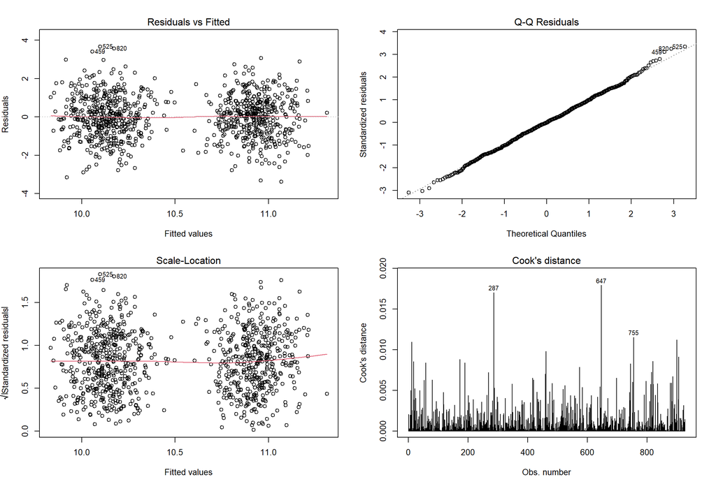

Model Diagnostics - Best Model

# Building a Fair Risk Framework: From Insight to Action

Traditional diversity risk assessments often fall into a troubling pattern: they end up automatically flagging certain team types (like Sales) as “high risk” simply because they start from a lower baseline. This approach is both unfair to those teams and strategically counterproductive.

Through my reading of organizational justice research and fairness frameworks in analytics, I understood that effective risk assessment requires accounting for contextual differences rather than applying uniform standards. Academic literature on organizational measurement consistently emphasizes the importance of peer-to-peer comparisons and relative performance metrics - insights I wanted to apply to create a more sophisticated framework.

I needed a framework that was both accurate and fair - one that identified teams genuinely struggling with diversity challenges while recognizing strong performers even within historically challenging contexts. Drawing on research methodologies I’d studied in behavioral economics and organizational psychology papers, I developed a multi-factor scoring system that addresses these challenges.

Fair Risk Assessment Results - Balanced and Actionable

| risk_category | Team_Count | Avg_UG | Pct_Sales_Teams | Avg_Risk_Score |
| --- | --- | --- | --- | --- |
| Low Risk | 553 | 11.1 | 47.6 | 0.0 |
| Medium Risk | 288 | 9.9 | 58.0 | 0.8 |
| High Risk | 85 | 8.9 | 56.5 | 1.4 |
| Critical Risk | 1 | 7.1 | 100.0 | 2.0 |

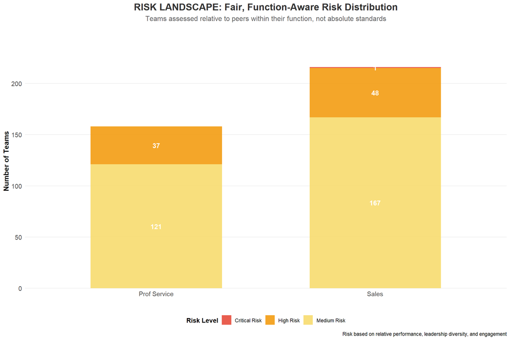

Fair Risk Assessment Distribution

# Team Size Analysis: Debunking the Scaling Myth

One of the most important insights came from systematically analyzing the team size patterns. The conventional wisdom suggested that larger teams would be harder to manage for diversity outcomes, but the data told a different story entirely.

Team Size vs Diversity Performance - No Scaling Challenge Found

| size_category | Function | avg_ug | team_count | Function_Label |
| --- | --- | --- | --- | --- |
| Medium (21-40) | 1 | 10.1 | 263 | Sales |
| Medium (21-40) | 2 | 11.0 | 236 | Professional Service |
| Large (41-60) | 1 | 10.1 | 216 | Sales |
| Large (41-60) | 2 | 10.9 | 212 | Professional Service |

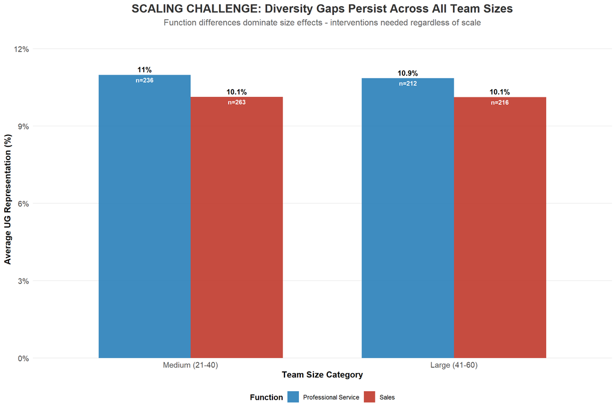

Team Size Analysis - The Scaling Challenge Myth

This finding was crucial because it meant that:

1. **Size-based interventions would be ineffective** - focusing on “large team management” wouldn’t address the real drivers of diversity gaps
2. **Function-specific factors were the real drivers** - whatever caused Sales teams to underperform operated independently of team size
3. **Our risk assessment needed to focus on function, not structure** - organizational design wasn’t the primary challenge

# Strategic Recommendations: From Analysis to Action

Based on this comprehensive analysis, I recommend a four-pronged strategic approach that moves beyond generic diversity initiatives toward targeted, evidence-based interventions:

## 1. Implement Function-Specific Diversity Strategies

**For Sales Teams:** - Partner with universities and organizations that serve underrepresented communities - Redesign job requirements to focus on core competencies rather than traditional qualifications - Create mentorship programs connecting Sales professionals with UG talent - Establish UG representation targets that are ambitious but realistic relative to Sales industry benchmarks

**For Professional Service Teams:** - Focus on maintaining and improving already strong performance - Create leadership development pipelines to increase female leadership - Share best practices with Sales teams to accelerate organizational learning

## 2. Embed Diversity into Engagement and Performance Initiatives

The diversity-performance link creates opportunities for integrated strategies: - Include diversity metrics in team performance dashboards alongside engagement scores - Train managers to understand how team composition affects performance outcomes - Recognize and reward teams that achieve both diversity and performance excellence - Use engagement survey results to identify teams where diversity initiatives might have dual benefits

## 3. Adopt the Fair Risk Framework for Annual Planning

Replace one-size-fits-all diversity targets with the evidence-based risk framework: - Conduct quarterly risk assessments to identify teams needing intervention - Set function-aware targets that recognize different baseline challenges - Focus intensive resources on the small number of Critical Risk teams - Celebrate and learn from Low Risk teams in all functions

## 4. Build Systematic Measurement and Learning Capabilities

This analysis demonstrates the power of rigorous diversity analytics: - Establish regular diversity data collection and analysis cycles - Train HR business partners to interpret and act on diversity analytics - Create feedback loops connecting intervention efforts to measurable outcomes - Build predictive capabilities to identify teams at risk before problems become severe

# Conclusion: From Questions to Strategic Blueprint

This analysis began with a simple question about organizational diversity performance. It evolved into something much more sophisticated: a comprehensive understanding of the structural factors that drive diversity outcomes and a strategic framework for improving them.

The key insight isn’t just that diversity matters - it’s that diversity outcomes are predictable, measurable, and improvable through targeted interventions based on evidence rather than assumptions.

Comprehensive Analysis Summary - From Data to Strategic Action

[output not shown]

**This analysis didn’t just answer a question - it created a blueprint for strategic action.**

The framework we’ve developed can be applied beyond diversity to other organizational challenges: retention, performance, innovation, or any outcome where understanding structural drivers can inform targeted interventions.

The methodology - moving from simple questions through rigorous analysis to actionable insights - represents a new model for evidence-based people strategy. In an era where every organization claims to be “data-driven,” this analysis demonstrates what that actually looks like in practice.

Most importantly, this work transforms diversity from a philosophical commitment into a strategic capability. We now have the tools to predict where diversity will thrive, identify where it will struggle, and intervene with precision rather than hope.

The question that started this journey - “Are we doing well on diversity?” - turns out to have been the wrong question. The right question is: “How can we use evidence to build systematic capability for diversity success?” This analysis provides the answer.